# Supplementary Data 2

### Supplementary code and figures accompanying *Combining gene mutation with gene expression data improves outcome prediction in myelodysplastic syndromes*

This document contains the complete code used in the analysis. It is purely written in `R` using a series of `R` and `Bioconductor` packages. This report has been generated using the `knitr` R package (http://yihui.name/knitr/). For a complete list of packages and their versions please have a look at the end of this document.

### Libraries

Load necessary libraries

```r
library(limma)
library(org.Hs.eg.db)
library(RColorBrewer)
library(AnnotationDbi)
library(affy)
library(gcrma)
library(hgu133plus2.db )
library(VennDiagram)
library(org.Hs.eg.db)
library(GenomicRanges)
library(GenomicFeatures)
library(rtracklayer)
library(biomaRt)
library(glmnet)
library(survival)
library(Hmisc)
library(randomForestSRC)
set1 = c(brewer.pal(9,"Set1"), brewer.pal(8, "Dark2"))
source("suppData/mg14.R")
```

## 1. Data preprocessing

### 1. Normalisation of expression data

This uses the `affy` package and `gcrma` correction. Pretty standard We assume you have downloaded the complete tarball GSE58831_RAW.tar from GEO http://www.ncbi.nlm.nih.gov/geo/query/acc.cgi?acc=GSE58831 and untared the archive and gunzipped all .CEL files into directory `GSE58831`.

```r
celFiles <- dir("GSE58831", pattern = ".CEL", full.names = T)
celFiles
```

```
##   [1] "GSE58831/GSM1420393_MDS009.CEL" "GSE58831/GSM1420394_MDS011.CEL" "GSE58831/GSM1420395_MDS012.CEL"
##   [4] "GSE58831/GSM1420396_MDS014.CEL" "GSE58831/GSM1420397_MDS015.CEL" "GSE58831/GSM1420398_MDS025.CEL"
##   [7] "GSE58831/GSM1420399_MDS027.CEL" "GSE58831/GSM1420400_MDS029.CEL" "GSE58831/GSM1420401_MDS184.CEL"
##  [10] "GSE58831/GSM1420402_MDS185.CEL" "GSE58831/GSM1420403_MDS186.CEL" "GSE58831/GSM1420404_MDS187.CEL"
##  [13] "GSE58831/GSM1420405_MDS188.CEL" "GSE58831/GSM1420406_MDS189.CEL" "GSE58831/GSM1420407_MDS033.CEL"
##  [16] "GSE58831/GSM1420408_MDS043.CEL" "GSE58831/GSM1420409_MDS050.CEL" "GSE58831/GSM1420410_MDS052.CEL"
##  [19] "GSE58831/GSM1420411_MDS053.CEL" "GSE58831/GSM1420412_MDS190.CEL" "GSE58831/GSM1420413_MDS054.CEL"
##  [22] "GSE58831/GSM1420414_MDS055.CEL" "GSE58831/GSM1420415_MDS057.CEL" "GSE58831/GSM1420416_MDS058.CEL"
##  [25] "GSE58831/GSM1420417_MDS059.CEL" "GSE58831/GSM1420418_MDS191.CEL" "GSE58831/GSM1420419_MDS061.CEL"
##  [28] "GSE58831/GSM1420420_MDS062.CEL" "GSE58831/GSM1420421_MDS063.CEL" "GSE58831/GSM1420422_MDS066.CEL"
##  [31] "GSE58831/GSM1420423_MDS067.CEL" "GSE58831/GSM1420424_MDS068.CEL" "GSE58831/GSM1420425_MDS069.CEL"
##  [34] "GSE58831/GSM1420426_MDS071.CEL" "GSE58831/GSM1420427_MDS072.CEL" "GSE58831/GSM1420428_MDS074.CEL"
##  [37] "GSE58831/GSM1420429_MDS075.CEL" "GSE58831/GSM1420430_MDS076.CEL" "GSE58831/GSM1420431_MDS079.CEL"
##  [40] "GSE58831/GSM1420432_MDS080.CEL" "GSE58831/GSM1420433_MDS081.CEL" "GSE58831/GSM1420434_MDS082.CEL"
##  [43] "GSE58831/GSM1420435_MDS084.CEL" "GSE58831/GSM1420436_MDS085.CEL" "GSE58831/GSM1420437_MDS087.CEL"
```

[output cut: 44 more lines]

```r
affyBatch <- read.affybatch(filenames = celFiles)
gset = gcrma(affyBatch)
```

```
## Adjusting for optical effect................................................................................................................................................................................Done.
## Computing affinities.Done.
## Adjusting for non-specific binding................................................................................................................................................................................Done.
## Normalizing
## Calculating Expression
```

```r
samples = sub("_.+","", sampleNames(gset))
sampleNames(gset) = samples
```

Now merge probes to genes by the means of all probes mapping to a particular entrez id

```r
tab <- select(hgu133plus2.db, keys = keys(hgu133plus2.db), columns = c("ENTREZID"))
e <- exprs(gset)
geneExpr <- t(sapply(split(tab[,1], tab[,2]), function(ids){
                    colMeans(e[ids,,drop=FALSE])
                }))
rm(tab,e)
```

### 2. Load mutation and clinical data

Load clinical data for 159 MDS patients and 17 normals from Supplementary Table S1.

```r
mdsData <- read.table("suppData/SuppTableS1GEO.txt", sep="\t", header=TRUE, check.names=FALSE) ## A tab-delimited version of Supplementary Table S1
head(mdsData)
```

```
##      PDID  GEPID      GEOID                  File Type Gender Age WHO_category Survival_days Status
## 1 PD6175a  GER20 GSM1420393 GSM1420393_MDS009.CEL  MDS      1  76           RA          2575      0
## 2 PD6173a  GER24 GSM1420394 GSM1420394_MDS011.CEL  MDS      1  61           RA           674      0
## 3 PD6185a  GER25 GSM1420395 GSM1420395_MDS012.CEL  MDS      1  50         RAEB          2514      0
## 4 PD6184a   GER4 GSM1420396 GSM1420396_MDS014.CEL  MDS      1  42         RAEB          2550      0
## 5 PD6183a   GER5 GSM1420397 GSM1420397_MDS015.CEL  MDS      1  51         RAEB          2549      0
## 6 PD6198a MDS135 GSM1420398 GSM1420398_MDS025.CEL  MDS      0  61      RCMD-RS          1057      1
##   AML_progression_days AML_status                                                 Karyotype Cytogenetic_risk  IPSS WPSS
## 1                   NA         NA 46, XX, t(1;3)(p33:p14), del(5)(q14;q34)[21] / 46, XX [4]                1 int-1 <NA>
## 2                   NA         NA               46, XX, del(5)(q14;q34) [21], inv9(q11;q12)                1 int-1 <NA>
## 3                   NA         NA                                   46, XX, del(5)(q14;q34)                0 int-1 <NA>
## 4                   NA         NA                                   46, XX, del(5)(q14;q34)                0 int-1 <NA>
## 5                   NA         NA                 46, XX, del(5)(q14;q34) [20] / 46, XX [5]                0 int-1 <NA>
## 6                   NA          0                                                    46, XY                0   low <NA>
##   Transfusion_dep Serum_ferritin PB_cytopenia Haemoglobin Absoulte_neutrophile_count Platelet_count BM_blasts_pct
```

[output cut: 34 more lines]

```r
ix <- setdiff(na.omit(match(samples, mdsData$GEOID)), which(is.na(mdsData$PDID))) ## All MDS samples with expression and seq data
normalSamples <- as.character(mdsData$GEOID[mdsData$Type=="Normal"])
```

Define mappings

```r
GEO2PD <- as.character(mdsData$PDID)
names(GEO2PD) <- mdsData$GEOID
PD2GEO <- as.character(mdsData$GEOID)
names(PD2GEO) <- mdsData$PDID
```

#### Clinical summary statistics

```r
f <- function(x) cat(paste(median(x, na.rm=TRUE), " median; ", min(x, na.rm=TRUE),"-",max(x, na.rm=TRUE), " range; ", sum(is.na(x)), " missing", sep=""),"\n")
mdsIx <- !is.na(mdsData$GEOID[mdsData$Type=="MDS"]) ## All MDS samples with expression data
table(mdsData$Gender[mdsIx])
```

```
##
##   0   1
## 102  57
```

```r
f(mdsData$Age[mdsIx])
```

```
## 67 median; 19-87 range; 22 missing
```

```r
table(mdsData$WHO_category[mdsIx])
```

```
##
##     5q- AML-MDS    CMML      RA    RAEB  RAEB 1  RAEB 2   RAEB1   RAEB2    RARS  RARS-T    RCMD RCMD-RS
##       6       7       7      13      14      13      23       1       5      14       6      27      22
```

```r
f(as.numeric(as.character(mdsData$BM_blasts_pct[mdsIx])))
```

```
## 4 median; 0-63 range; 34 missing
```

```r
f(as.numeric(as.character(mdsData$Ring_sideroblasts_pct[mdsIx])))
```

```
## 0.5 median; 0-94 range; 50 missing
```

```r
f(mdsData$Haemoglobin[mdsIx])
```

```
## 9.5 median; 4.5-14.6 range; 32 missing
```

```r
f(mdsData$Absoulte_neutrophile_count[mdsIx])
```

```
## 1.848 median; 0.08-920 range; 37 missing
```

```r
f(mdsData$Platelet_count[mdsIx])
```

```
## 154 median; 10-45000 range; 25 missing
```

```r
table(mdsData$PB_cytopenia[mdsIx])
```

```
##
##  0  1
## 52 72
```

### 3. Match expression and clinical data

Incrementally construct the design matrix

```r
design = cbind(offset=1,mdsData[ix, grep("SF3B1|TET2|SRSF2|ASXL1|DNMT3A|RUNX1|U2AF1|TP53|EZH2|IDH2|STAG2|ZRSR2|CBL|BCOR|NRAS|JAK2|CUX1|IDH1|KRAS|PHF6|EP300|GATA2|NPM1|MLL2|PTPN11|CREBBP|KIT|MPL|NF1|WT1|IRF1|RAD21|ATRX|CDKN2A|ETV6|KDM6A|CEBPA|FLT3|GNAS|PTEN|SH2B3|BRAF|CTNNA1", colnames(mdsData))]) # oncogenic mutations
minF=5 ## Minimal number of alterations
design = design[,colSums(design)>=minF]
rownames(design) <- mdsData$GEOID[ix]
```

Cytogenetics

```r
cytoImputed <- mdsData[ix, grep("rearr|del|tri|abn|complex|other", colnames(mdsData), value=TRUE)[-12:-11]]
cytoImputed <- cytoImputed[,colSums(cytoImputed, na.rm=TRUE)>0]
design <- cbind(design,  cytoImputed[,colSums(cytoImputed, na.rm=TRUE)>=minF], Gender=mdsData[ix,"Gender"], Age=scale(mdsData[ix,"age_imp"], center=TRUE, scale=FALSE))
```

Include 17 normal samples

```r
n <- nrow(design)
design <- rbind(design, matrix(0, nrow=17, ncol=ncol(design), dimnames = list(NULL,colnames(design))))
design <- cbind(design, Normal=c(rep(0,n), rep(1,17)))
design[,1] <- 1
design[n+1:17,"Age"] <- NA #mean(design[1:n,"Age"])
design[n+1:17,"Gender"] <- geneExpr["7503",normalSamples] > 5 ## XIST expression
rownames(design)[n+1:17] <- normalSamples
design <- design[,c(1:17,20,18:19)]
```

Impute missing by mean

```r
design0 <- design
for(j in 1:ncol(design))
    design[is.na(design[,j]),j] <- mean(design[,j], na.rm=TRUE)

head(design)
```

```
##            offset SF3B1 TET2 SRSF2 ASXL1 DNMT3A RUNX1 U2AF1 TP53 EZH2 STAG2 ZRSR2 JAK2 del(5q) tri(8) del(12p) del(20q)
## GSM1420393      1     0    0     0     0      0     0     0    0    0     0     0    0       1      0        0        0
## GSM1420394      1     0    0     0     0      0     0     1    0    0     0     0    0       1      0        0        0
## GSM1420395      1     0    0     0     0      0     0     0    0    0     0     0    0       1      0        0        0
## GSM1420396      1     0    0     0     0      0     0     0    0    0     0     0    1       1      0        0        0
## GSM1420397      1     0    0     0     1      0     0     0    0    0     0     0    0       1      0        0        0
## GSM1420398      1     0    0     0     0      0     0     0    0    0     0     0    0       0      0        0        0
##            Normal Gender     Age
## GSM1420393      0      1  10.589
## GSM1420394      0      1  -4.411
## GSM1420395      0      1 -15.411
## GSM1420396      0      1 -23.411
## GSM1420397      0      1 -14.411
## GSM1420398      0      0  -4.411
```

Define colors

```r
colMutations = c(brewer.pal(8,"Set1")[-6], rev(brewer.pal(8,"Dark2")), brewer.pal(7,"Set2"))[c(1:12,16:19,13:15)]
o <- order(apply(col2rgb(colMutations),2,rgb2hsv)[1,])
colMutations <- colMutations[rev(o)][(4*1:19 +15) %% 19 + 1]
names(colMutations) <- colnames(design)[-1]
```

Show a venn diagram with the overlap

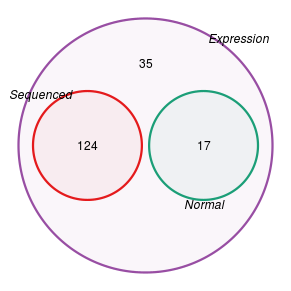

```r
par(bty="n", mgp = c(2,.33,0), mar=c(3,3,1,0)+.1, las=1, tcl=-.25)
grid.newpage()
pushViewport(viewport(w = .9, h = .9))
grid.draw(venn.diagram(list(Sequenced=mdsData$GEOID[!is.na(mdsData$PDID)], Expression = samples, Normal=normalSamples), filename=NULL, lty=1,
                col=colMutations[1:3], fill=colMutations[1:3], alpha=0.05, euler.d=TRUE, fontfamily="Helvetica", cat.fontfamily="Helvetica", cat.fontface="italic", euler.diagram=TRUE))
```

## 2. Model fitting

We use the lmFit function from the `limma` package. This comes with a whole series of powerful and reliable tests.

```r
glm = lmFit(geneExpr[,rownames(design)], design = design )
glm = eBayes(glm)
```

### 1. F-statistic for all but offset

Here we want to determine all genes which are associated with any covariate. This will be based on an F-statistic. lmFit also tests wether the offset is different from zero (trivially true).

```r
F.stat <- classifyTestsF(glm[,-1],fstat.only=TRUE) # remove offset
glm$F <- as.vector(F.stat)
df1 <- attr(F.stat,"df1")
df2 <- attr(F.stat,"df2")
if(df2[1] > 1e6){ # Work around bug in R 2.1
    glm$F.p.value <- pchisq(df1*glm$F,df1,lower.tail=FALSE)
}else
    glm$F.p.value <- pf(glm$F,df1,df2,lower.tail=FALSE)
```

#### Random model

Compare to a model where all values of the covariates are randomly permuted. If all model assumptions were correct, this wouldn't be needed.

```r
set.seed(42)
rlm <- lmFit(geneExpr[,rownames(design)], apply(design, 2, sample))
rlm <- eBayes(rlm)
F.stat <- classifyTestsF(rlm[,-1],fstat.only=TRUE)
rlm$F <- as.vector(F.stat)
df1 <- attr(F.stat,"df1")
df2 <- attr(F.stat,"df2")
if(df2[1] > 1e6){ # Work around bug in R 2.1
    rlm$F.p.value <- pchisq(df1*rlm$F,df1,lower.tail=FALSE)
}else
    rlm$F.p.value <- pf(rlm$F,df1,df2,lower.tail=FALSE)
```

#### Explained variance by different categories

The F-statistic is directly related to the R2.

```r
F.stat <- classifyTestsF(glm[,2:16],fstat.only=TRUE) ## All genetics & cytogenetics
df1 <- attr(F.stat,"df1")
df2 <- attr(F.stat,"df2")
F.p.value <- pchisq(df1*F.stat,df1,lower.tail=FALSE)

R.stat <- classifyTestsF(rlm[,2:16],fstat.only=TRUE) ## Random

Rall = 1 - 1/(1 + glm$F * (ncol(design)-1)/(nrow(design)-ncol(design)))
Rgenetics = 1 - 1/(1 + F.stat * 15/(nrow(design)-ncol(design)))
Pgenetics = 1 - 1/(1 + R.stat * 15/(nrow(design)-ncol(design)))
names(Rgenetics) <- names(Pgenetics) <- names(Rall) <-  rownames(geneExpr)
```

Plot the variance explained by genetics

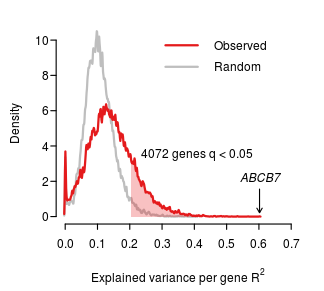

```r
par(bty="n", mgp = c(2,.33,0), mar=c(3,2.5,1,1)+.1, las=1, tcl=-.25, xpd=NA)
d <- density(Pgenetics,bw=1e-3)
f <- 1#nrow(gexpr)/512
plot(d$x, d$y * f, col='grey', xlab=expression(paste("Explained variance per gene ", R^2)), main="", lwd=2, type="l", ylab="", xlim=c(0,0.7))
title(ylab="Density", line=1.5)
d <- density(Rgenetics, bw=1e-3)
r <- min(Rgenetics[p.adjust(F.p.value,"BH")<0.05])
x0 <- which(d$x>r)
polygon(d$x[c(x0[1],x0)], c(0,d$y[x0])* f, col=paste(set1[1],"44",sep=""), border=NA)
lines(d$x, d$y* f, col=set1[1], lwd=2)
#points(d$x[x0[1]], d$y[x0[1]]*f, col=set1[1], pch=16)
text(d$x[x0[1]], d$y[x0[1]]*f, pos=4, paste(sum(Rgenetics > r), "genes q < 0.05"))
arrows(Rgenetics["22"], par("usr")[4]/7, Rgenetics["22"], par("usr")[4]/50, length=0.05)
text(Rgenetics["22"], par("usr")[4]/8, "ABCB7", font=3, pos=3)
legend("topright", bty="n", col=c(set1[1], "grey"), lty=1, c("Observed","Random"), lwd=2)
```

#### Predictions

```r
glmPrediction <- glm$coefficients %*% t(design)
rlmPrediction <- rlm$coefficients %*% t(design)
```

#### ABCB7 expression

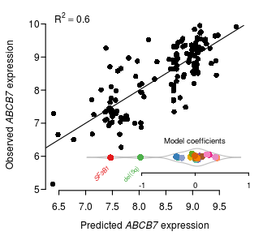

```r
par(bty="n", mgp = c(1.5,.33,0), mar=c(2.5,2.5,1,1)+.1, las=1, tcl=-.25)
plot(glmPrediction["22",], geneExpr["22",rownames(design)], ylab=expression(paste("Observed ",italic("ABCB7"), " expression")), xlab=expression(paste("Predicted ",italic("ABCB7"), " expression")), pch=16, cex=.8)
abline(0,1)
u <- par("usr")
par(xpd=NA)
y <- glm$coefficients["22",-1]+glm$coefficients["22",1]
u <- par("usr")
x0 <- rep(u[3]+1,ncol(design)-1)
y0 <- u[4] + 0.05*(u[4]-u[3]) - rank(-y)/length(y) * (u[4]-u[3])/1.2
d <- density(y)
lines(d$x, d$y/5+1+u[3], col="grey")
lines(d$x, -d$y/5+1+u[3], col="grey")
points(x=y, y=x0+violinJitter(y, magnitude=0.25)$y, col=colMutations, pch=16)
text(x=glm$coefficients["22",1], y= 1.5 +u[3], "Model coefficients", cex=0.8)
w <- glm$p.value["22",-1] < 0.01
rotatedLabel(y[w], x0[w]+0.1, labels=colnames(design)[-1][w], font=ifelse(grepl("[[:lower:]]", colnames(design)[-1]),1,3)[w], cex=.66, pos=1, col=colMutations[w])
axis(at=-1:1 + glm$coefficients["22",1], labels=-1:1, side=1, cex.axis=.8, line=-1, mgp = c(1.5,.05,0), tcl=-.15)
#mtext(at=l$coefficients[1], line=-2, side=1, "Coefficients", cex=.8)
text(u[1],u[4], substitute(paste(R^2==r),list(r=round(Rgenetics["22"],2))), pos=4)
```

```r
#text(u[1],u[4]-(u[4]-u[3])*0.1, substitute(paste(R["Genetics"]^2==r),list(r=round(Rgenetics["22"],2))), pos=4)
```

### 2. Significant effects per covariate

Prepare the test results using a hierarchical procedure: 1. Adjust down transcripts using F-stat 2. Adjust along covariates

```r
testResults <- decideTests(glm, method="hierarchical",adjust.method="BH", p.value=0.05)[,-1]
significantGenes <- sapply(1:ncol(testResults), function(j){
            c <- glm$coefficients[testResults[,j]!=0,j+1]
            table(cut(c, breaks=c(-5,seq(-1.5,1.5,l=7),5)))
        })
colnames(significantGenes) <- colnames(testResults)
```

#### Barplot

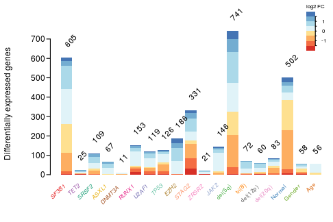

```r
par(bty="n", mgp = c(2.5,.33,0), mar=c(3,3.3,2,0)+.1, las=2, tcl=-.25)
b <- barplot(significantGenes, las=2, ylab = "Differentially expressed genes", col=brewer.pal(8,"RdYlBu"), legend.text=FALSE , border=0, xaxt="n")#, col = set1[simple.annot[names(n)]], border=NA)
rotatedLabel(x0=b, y0=rep(10, ncol(significantGenes)), labels=colnames(significantGenes), cex=.7, srt=45, font=ifelse(grepl("[[:lower:]]", colnames(design))[-1], 1,3), col=colMutations)
clip(0,30,0,1000)
#text(b+0.2, colSums(n)+50, colSums(n), pos=3, cex=.7, srt=90)
x0 <- 21.5
image(x=x0+c(0,0.8), y=par("usr")[4]+seq(-100,100,l=9), z=matrix(1:8, ncol=8), col=brewer.pal(8,"RdYlBu"), add=TRUE)
text(x=x0+1.5, y=par("usr")[4]+seq(-50,50,l=3), format(seq(-1,1,l=3),2), cex=0.66)
lines(x=rep(x0+.8,2), y=par("usr")[4]+c(-75,75))
segments(x0+.8,par("usr")[4]+seq(-75,75,l=7),x0+.9,par("usr")[4]+seq(-75,75,l=7))
text(x0+.8, par("usr")[4]+125, "log2 FC", cex=.66)
rotatedLabel(b-0.1, colSums(significantGenes), colSums(significantGenes), pos=3, cex=, srt=45)
```

Associated mutations per transcript:

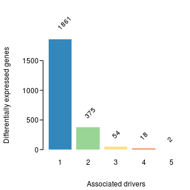

```r
par(bty="n", mgp = c(2.5,.33,0), mar=c(3,3.3,3,0)+.1, las=1, tcl=-.25)
t <- table(rowSums(abs(testResults[,1:16])))
b <- barplot(t[-1],ylab="Differentially expressed genes", col=rev(brewer.pal(7, "Spectral")[-(4:5)]), border=NA)
rotatedLabel(b-0.1, t[-1], t[-1], pos=3, cex=1, srt=45)
title(xlab="Associated drivers", line=2)
```

#### Venn diagrams for significant effects

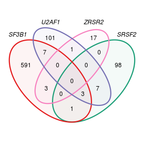

```r
v <- apply(testResults!=0,2, which)
par(bty="n", mgp = c(2,.33,0), mar=c(3,3,1,0)+.1, las=1, tcl=-.25)
grid.newpage()
pushViewport(viewport(w = .9, h = .9))
w <- c("SF3B1","SRSF2","U2AF1","ZRSR2")
grid.draw(venn.diagram(v[w], filename=NULL, lty=1, col=colMutations[w][c(1,3,4,2)], fill=colMutations[w], alpha=0.05, euler.d=TRUE, fontfamily="Helvetica", cat.fontfamily="Helvetica", cat.fontface="italic"))
```

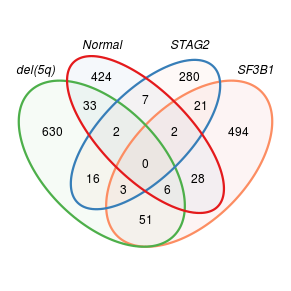

```r
grid.newpage()
pushViewport(viewport(w = .9, h = .9))
w <- names(sort(colSums(testResults!=0), decreasing = TRUE))[1:4]
grid.draw(venn.diagram(v[w], filename=NULL, lty=1, col=colMutations[w], fill=colMutations[w], alpha=0.05, euler.d=TRUE, fontfamily="Helvetica", cat.fontfamily="Helvetica", cat.fontface="italic"))
```

#### Chromosomal distribution

```r
chr = factor(sapply(AnnotationDbi::mget(rownames(geneExpr), org.Hs.egCHR, ifnotfound=NA), `[`,1), levels=c(1:22, "X","Y","MT"))
chromTable <- apply(testResults,2, function(x) table(chr[x!=0]))
```

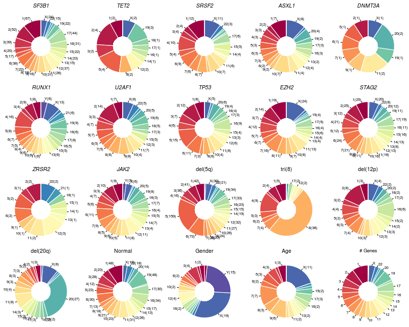

```r
par(bty="n", mgp = c(0.5,0.5,0), las=1, tcl=-.25, font.main=3, mfrow=c(4,5), xpd=NA, mar=c(0,0,1.5,0))
for(j in 1:ncol(testResults)){
    n <- sum(testResults[,j]!=0)
    pie(chromTable[,j], col=colorRampPalette(brewer.pal(11,'Spectral'))(24), border="white",  radius=0.8, init.angle=90, labels=ifelse(chromTable[,j]/sum(chromTable[,j]) > 0.02, paste("",rownames(chromTable), "(" ,chromTable[,j], ")",sep=""),""))
    title(main = colnames(chromTable)[j], font.main = ifelse(grepl("[[:lower:]]", colnames(chromTable)[j]), 1,3), cex.main=1.33)
    symbols(0,0,circles=.3, inches=FALSE, col="white", bg="white", lty=0, add=TRUE)
    #symbols(0,0,circles=.8*(1-sqrt(n/max(colSums(testResults!=0)))), col="white", add=TRUE, lty=0, bg="white", inches=FALSE)
    #cat(n,"\n")
}
t <- table(chr)
pie(t, col=colorRampPalette(brewer.pal(11,'Spectral'))(24), border="white",  radius=0.8, cex.main=1.33, labels=ifelse(t/sum(t) > 0.02, names(t),""), init.angle=90)
symbols(0,0,circles=.3, inches=FALSE, col="white", bg="white", lty=0, add=TRUE)
title(main = "# Genes", font.main = ifelse(grepl("[[:lower:]]", colnames(chromTable)[j]), 1,3))
```

### 3. Heatmaps for Figure 1b

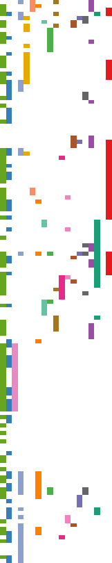

```r
par(bty="n", mgp = c(2,.33,0), mar=rep(0,4), las=1, tcl=-.25, xpd=NA)
plot(NA,NA, xlim=c(0,ncol(design)-1), ylim=c(0,nrow(design)), xaxt="n", yaxt="n", xlab="",ylab="", xaxs="i", yaxs="i")
z <- design[,-1]
h <- hclust(dist(z[,1:16]))
j <- hclust(dist(t(z)))
rasterImage(sapply(1:ncol(z), function(i) ifelse(z[,i]>0, colMutations[i-1], "#FFFFFF"))[h$order,j$order], 0, 0, ncol(design)-1, nrow(design), interpolate=FALSE)
```

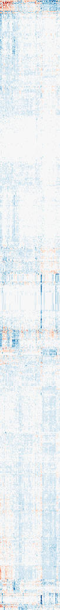

```r
par(bty="n", mgp = c(2,.33,0), mar=rep(0,4), las=1, tcl=-.25, xpd=NA)
w <- names(sort(Rgenetics, decreasing = TRUE)[1:1000])
z <- geneExpr[w,]-rowMeans(geneExpr[w,])
h <- hclust(dist(z))
i <- hclust(dist(t(z)))
plot(NA,NA, xlim=c(0,ncol(geneExpr)), ylim=c(0,1000), xaxt="n", yaxt="n", xlab="",ylab="", xaxs="i", yaxs="i")
rasterImage(matrix(brewer.pal(11,"RdBu")[cut(z[h$order,i$order], 12)], ncol=ncol(geneExpr)), 0,0,ncol(geneExpr),1000, interpolate=FALSE)
```

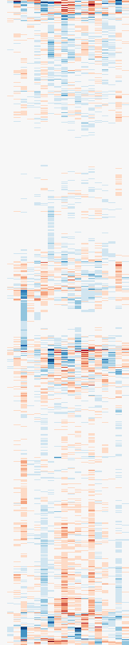

```r
par(bty="n", mgp = c(2,.33,0), mar=rep(0,4), las=1, tcl=-.25, xpd=NA)
plot(NA,NA, xlim=c(0,ncol(design)-1), ylim=c(0,1000), xaxt="n", yaxt="n", xlab="",ylab="", xaxs="i", yaxs="i")
rasterImage(matrix(brewer.pal(11,"RdBu")[cut(glm$coefficients[w,-1][h$order,j$order], seq(-3,3,l=12))], ncol=ncol(design)-1), 0,0,ncol(design)-1,1000, interpolate=FALSE)
```

### 4. Test for gene and cytogenetic interactions

Here we want to compare how mutational co-occurrence and the sets of transcriptional changes are interlinked

```r
genomicData = mdsData[,colnames(design)[2:17]]
interactions <- interactionsGenes <- sapply(1:ncol(genomicData), function(i) sapply(1:ncol(genomicData), function(j) {f<- try(fisher.test(genomicData[,i], genomicData[,j]), silent=TRUE); if(class(f)=="try-error") 0 else ifelse(f$estimate>1, -log10(f$p.val),log10(f$p.val))} ))
oddsRatio <- oddsGenes <- sapply(1:ncol(genomicData), function(i) sapply(1:ncol(genomicData), function(j) {f<- try(fisher.test(genomicData[,i] + .5, genomicData[,j] +.5), silent=TRUE); if(class(f)=="try-error") f=NA else f$estimate} ))
w <- p.adjust(glm$F.p.value,"BH")<0.05
oddsExpression <- sapply(1:ncol(genomicData), function(i) sapply(1:ncol(genomicData), function(j) {f<- try(fisher.test(abs(testResults[w,i]), abs(testResults[w,j])), silent=TRUE); if(class(f)=="try-error") f=NA else f$estimate} ))
interactionsExpression <- sapply(1:ncol(genomicData), function(i) sapply(1:ncol(genomicData), function(j) {f<- try(fisher.test(abs(testResults[w,i]), abs(testResults[w,j])), silent=TRUE); if(class(f)=="try-error") 0 else ifelse(f$estimate>1, -log10(f$p.val),log10(f$p.val))} ))
oddsRatio[lower.tri(oddsRatio)] <- oddsExpression[lower.tri(oddsExpression)]
interactions[lower.tri(interactions)] <- interactionsExpression[lower.tri(interactions)]

diag(interactions) <- NA
diag(oddsRatio) <- NA
colnames(oddsRatio) <- rownames(oddsRatio) <- colnames(interactions) <- rownames(interactions) <- colnames(genomicData)
oddsRatio[10^-abs(interactions) > 0.05] = 1
oddsRatio[oddsRatio<1e-3] = 1e-4
oddsRatio[oddsRatio>1e3] = 1e4
logOdds=log10(oddsRatio)

reorder <- function(M, o){
    u <- M
    u[lower.tri(u)] <- t(M)[lower.tri(M)]
    u <- u[o,o]
    l <- M
    l[upper.tri(u)] <- t(M)[upper.tri(M)]
    l <- l[o,o]
    R <- u
    R[lower.tri(R)] <- l[lower.tri(R)]
    return(R)
}
```

Plot (*Note: This plot looks a little different as in the paper, where mutation data for all 738 patients is used on the upper panel*).

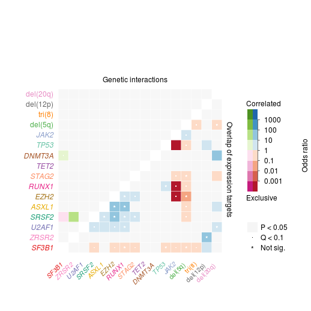

```r
par(bty="n", mgp = c(2,.5,0), mar=rep(4,4)+.1, las=2, tcl=-.33)
m <- nrow(oddsRatio)
n <- ncol(oddsRatio)
o = c(1,11,7,3,4,9,6,10,2,5,8,12:m)#h$order#c(h$order,(length(h$order) +1):ncol(interactions))
r <- reorder(log10(oddsRatio),o)
r[lower.tri(r)] <- NA
image(x=1:n, y=1:m, r, col=brewer.pal(9,"PiYG"), breaks = c(-4:0-.Machine$double.eps,0:4), xaxt="n", yaxt="n", xlab="",ylab="", xlim=c(0, n+4), ylim=c(0, n+4))
r <- reorder(log10(oddsRatio),o)
r[upper.tri(r)] <- NA
image(x=1:n, y=1:m, r, col=brewer.pal(9,"RdBu"), breaks = c(-4:0-.Machine$double.eps,0:4), add=TRUE)
mtext(side=2, at=1:n, colnames(oddsRatio)[o], font=ifelse(grepl('[[:lower:]]',colnames(oddsRatio)[o]),1,3), col=colMutations[1:16][o])
rotatedLabel(x0=1:n, y0=rep(0.5, n), colnames(oddsRatio)[o], font=ifelse(grepl('[[:lower:]]',colnames(oddsRatio)[o]),1,3), srt=45, cex=.9, col=colMutations[1:16][o])
abline(h = length(h$order)+.5, col="white", lwd=1)
abline(v = length(h$order)+.5, col="white", lwd=1)
abline(h=0:n+.5, col="white", lwd=.5)
abline(v=0:n+.5, col="white", lwd=.5)
text(x=n/2, y=m+.5, "Genetic interactions", pos=3)
text(x=n+1, y=m/2, "Overlap of expression targets", pos=3, srt=270)
q <- p.adjust(10^-abs(reorder(interactions,o)), method="BH")
p <- p.adjust(10^-abs(reorder(interactions,o)), method="holm")
w = arrayInd(which(q < .1), rep(m,2))
points(w, pch=".", col="white", cex=1.5)
w = arrayInd(which(p < .05), rep(m,2))
points(w, pch="*", col="white")
image(y = 1:8 +6, x=rep(n,2)+c(2,2.5)+1, z=matrix(c(1:8), nrow=1), col=brewer.pal(8,"PiYG"), add=TRUE)
image(y = 1:8 +6, x=rep(n,2)+c(2.5,3)+1, z=matrix(c(1:8), nrow=1), col=brewer.pal(8,"RdBu"), add=TRUE)
axis(side = 4, at = seq(1,7) + 6.5,  tcl=-.15, label=10^seq(-3,3), las=1, lwd=.5)
mtext(side=4, at=10, "Odds ratio", las=3, line=3)
par(xpd=NA)
text(x=n+2.2, y=15, "Correlated", pos=4)
text(x=n+2.2, y=6-.2, "Exclusive", pos=4)
points(x=rep(n,2)+3.5, y=1:2, pch=c("*","."))
image(x=rep(n,2)+c(2,3)+1, y=(3:4) -0.5, z=matrix(1), col=brewer.pal(3,"BrBG"), add=TRUE)
mtext(side=4, at=1:3, c("Not sig.", "Q < 0.1", "P < 0.05"), line=0.2)
```

### 5. Write output

```r
t= topTable(glm, number=Inf)
annot <- select(org.Hs.eg.db, rownames(t), c("SYMBOL","GENENAME","CHR","CHRLOC"))
t <- cbind(annot[!duplicated(annot$ENTREZID),1:5],signif(cbind(t, R2.genetics=Rgenetics[rownames(t)], P.R2.genetics=F.p.value[rownames(t)]), 3), P = signif(glm$p.value[rownames(t),],2),Test=testResults[rownames(t),])
write.table(t[order(-t$R2.genetics),], file=paste(Sys.Date(),"-SuppTable2.txt",sep=""), sep="\t", row.names = FALSE, quote=FALSE)
```

### Contrast against normals

```r
normalContrast <- rbind(rep(0,18), diag(1,18), rep(-1, 18))[c(1:17,20,18:19),]
colnames(normalContrast) <- setdiff(colnames(design)[2:20],"Normal")
normalContrast <- contrasts.fit(glm, normalContrast)
normalContrast <- eBayes(normalContrast)
```

### Expression of mutated genes

The next part will analyse how mutated genes themselves are expressed

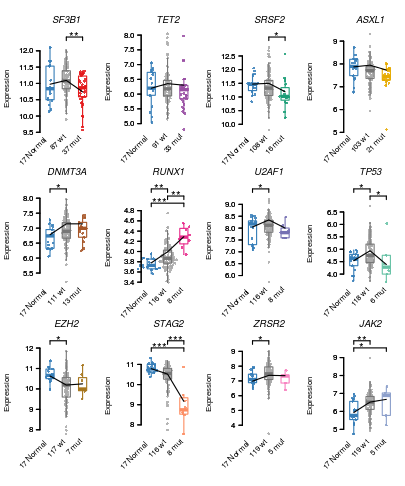

```r
par(bty="n", mgp = c(2.5,0.5,0), las=1, tcl=-.25, font.main=3)
layout(matrix(1:16, ncol=4, byrow = TRUE), heights=c(1,1,1,0.2))
w <- grep("[[:lower:]]", colnames(design), invert = TRUE)
p <- sapply(colnames(design)[w], function(i){
            geneId <- AnnotationDbi::get(i, revmap(org.Hs.egSYMBOL))

            c(  p = glm$p.value[geneId,c("Normal",i)],
            q = normalContrast$p.value[geneId,i])
        })
p[] <-  sig2star(p.adjust(p, "BH"), breaks=10^c(-.Machine$double.max.exp,-3:0),labels=c("***","**","*",""))
for(i in colnames(design)[w]){
    o <- colSums(p!="")[i]*.5 + (colSums(p!="")[i]>0)*.5
    par(mar=c(1.2,2.7, o +2,0.5)+.1)
    x <- design[,i]+1 -design[,"Normal"]
    geneId <- AnnotationDbi::get(i, revmap(org.Hs.egSYMBOL))
    v <- do.call("rbind", lapply(split(geneExpr[geneId, rownames(design)], x), violinJitter, magnitude=0.5))
    plot( sort(x) + v$y, v$x, ylab="", xaxt="n", xlab="",
            col=paste(c(colMutations[c('Normal',i)],"#AAAAAA"),"DD", sep="")[c(1,3,2)][sort(x)+1],
            xlim=c(-0.5,2.5), cex.main=1, pch = 16, cex=0.5, lwd=0)#genotypes[match(rownames(design), rownames(genotypes)),i]+1)
    title(ylab="Expression", line=2)
    title(main=i, line=o +.5)
    par(xpd=NA)
    boxplot(at=0:2, geneExpr[geneId, rownames(design)] ~ factor(design[,i] - design[,"Normal"]), add=TRUE, xaxt="n", boxwex=0.5, outline=FALSE, lty=1, outwex=0, staplewex=0, border=c(colMutations[c('Normal',i)],"#777777")[c(1,3,2)])
    l=0
    a = list(0:1,1:2, c(0,2))
    for(j in 3:1){
        if(p[j,i] != ""){
        axis(3, at=a[[j]], labels=NA, tcl=0.25, line=l+.5)
        mtext(side=3, at=a[[j]][1]+.5, p[j,i], line = l)
        l <- l+.5
    }
    }
    u <- par("usr")
    rotatedLabel(0:2, rep((u[3]+u[4])/2 - 0.4 * (u[4]-u[3])), paste(table(x),c("Normal", "wt", "mut")))
    y <- glm$coefficients[AnnotationDbi::get(i, revmap(org.Hs.egSYMBOL)),c("offset",i, "Normal")]
    lines(0:2, y[1] + c(y[3],0,y[2]))#, pch=21, bg="white",col=c(colMutations[c('normal',i)],"#AAAAAA")[c(1,3,2)], type="b", cex=1.25)
}
```

Volcano plot

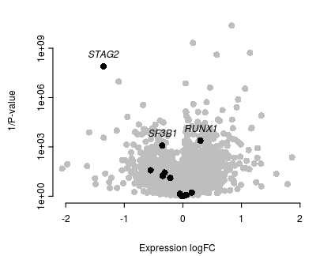

```r
par(bty="n", mgp = c(2,.33,0), mar=c(3,3,1,1)+.1,  tcl=-.25)
set.seed(42)
s <- sample(1:nrow(glm),500)
plot(glm$coefficients[s,-1], (1/glm$p.value[s,-1]), log="y", xlab="Expression logFC", ylab="1/P-value", col="grey", pch=16)
x <- sapply(colnames(design)[w], function(i) glm$coefficients[AnnotationDbi::get(i, revmap(org.Hs.egSYMBOL)),i])
y <-  (1/sapply(colnames(design)[w], function(i) glm$p.value[AnnotationDbi::get(i, revmap(org.Hs.egSYMBOL)),i]))
points(x, y, pch=16)
text(x,y,ifelse(y>1e2,names(x),""), pos=3, font=3)
```

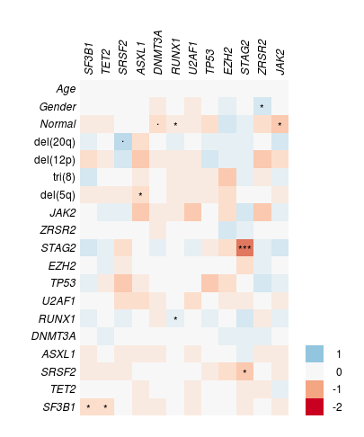

```r
par(bty="n", mgp = c(2.5,.5,0), mar=c(1,4,4,2)+.1,  tcl=-.25)
z <- glm$coefficients[unlist(AnnotationDbi::mget(colnames(design)[w], revmap(org.Hs.egSYMBOL))),-1]
n <- nrow(z)
m <- ncol(z)
image(x=1:n,y=1:m, z, col=colorRampPalette(brewer.pal(9,"RdBu"))(19), breaks=seq(-2,2,l=20), xaxt="n", yaxt="n", xlab="",ylab="", xlim=range(0:n)+c(0.5,2.5))
mtext(side=3, at=1:n, colnames(design)[w], las=2, font=3, line=0.2)
mtext(side=2, at=1:m, colnames(z), las=2, font=ifelse(grepl("[[:upper:]]", colnames(design))[-1], 3,1), line=0.2)
text(rep(1:n, m), rep(1:m,each=n), sig2star(p.adjust(glm$p.value[unlist(AnnotationDbi::mget(colnames(design)[w], revmap(org.Hs.egSYMBOL))),-1], method="BH")))
image(x=n+2 + c(-0.5,0.5), y=1:4, z=matrix(1:4, ncol=4), col=brewer.pal(5,"RdBu")[-5], add=TRUE)
mtext(side=4, at=1:4, text=-2:1, las=2, adj=1, line=1)
```

## 2. Principal components analysis

```r
pca <- prcomp(t(geneExpr))
```

### 1. Explained variance by principal components

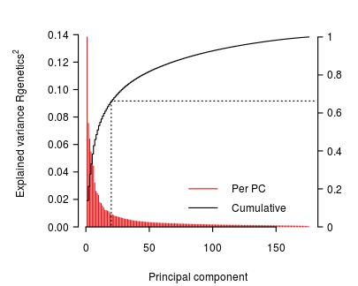

```r
par(bty="n", mgp = c(2.5,.5,0), mar=c(3,4,1,2)+.1, tcl=-.25, las=1)
plot(pca$sdev^2/sum(pca$sdev^2), type="h", col=set1[1], xlab="", ylab=expression(paste("Explained variance ", Rgenetics^2)) , ylim=c(0,0.15), yaxs="i")
mtext(side=1, "Principal component", line=2)
c <- cumsum(pca$sdev^2)/sum(pca$sdev^2)* pca$sdev[1]^2/sum(pca$sdev^2)
lines(c  , type="s")
axis(4, at = pretty(c(0,1))* pca$sdev[1]^2/sum(pca$sdev^2), labels=pretty(c(0,1)))
legend("bottomright", col=c(set1[1],"black"), lty=1, c("Per PC","Cumulative"), bty="n")
lines(c(180,20,20),c(c[20],c[20],0), lty=3)
```

### 2. Spatial clustering

We test wether samples with a given mutations cluster in the PCA world

```r
x = pca$x[rownames(design),1:20, drop=FALSE]
d = apply(design[,-1], 2, function(y) mean(sqrt(rowSums((x[y>0,,drop=FALSE] - rep(colMeans(x[y>0,]),each=sum(y>0)))^2)*rep(pca$sdev[1:20]^2/sum(pca$sdev[1:20]^2), each=sum(y>0)))))
d0 = apply(design[,-1], 2, function(y) sapply(1:1000, function(i) mean(sqrt(rowSums((x[sample(y)>0,,drop=FALSE] - rep(colMeans(x[sample(y)>0,]),each=sum(y>0)))^2)*rep(pca$sdev[1:20]^2/sum(pca$sdev[1:20]^2), each=sum(y>0))))))
```

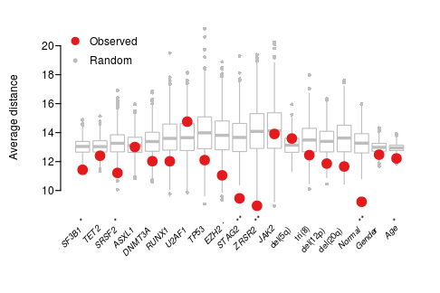

```r
par(bty="n", mgp = c(2,.33,0), mar=c(4,3,1,1)+.1, las=2, tcl=-.25, xpd=NA)
boxplot(d0, las=2, pch=16, cex=.5, staplewex=0, lty=1, border="grey", ylab="Average distance", xaxt="n", ylim=range(d0))
rotatedLabel(x0=1:length(d), y0 = par("usr")[3], names(d), font = ifelse(grepl("[[:upper:]]", names(d)), 3,1), cex=0.8, srt=45)
points(d, col=set1[1], pch=19, cex=1.3)
legend("topleft", bty="n", legend=c("Observed","Random"), pch=c(19,19), col=c(set1[1],"grey"), pt.cex=c(1,0.5))
p <-  colMeans(d0 < rep(d, each=1000)) + 1/1000
rotatedLabel(x0=1:length(d), y0 = par("usr")[3]-1.5, sig2star(p.adjust(p, method="BH")), cex=0.8, srt=45, pos=3)
```

### 3. PCA overview

Now plot a large panel with small multiples of the first two PCs overlaid with the mutation status of each gene.

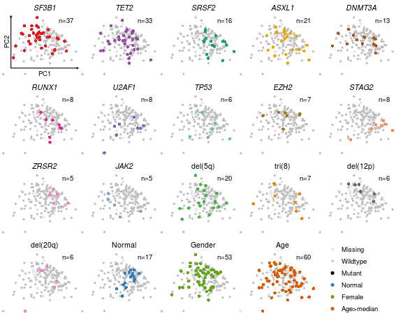

```r
par(bty="n", mgp = c(0,0.5,0), mar=c(1,1,1.5,0)+.1, las=1, tcl=-.25, font.main=3, mfrow=c(4,5), xpd=NA)
i<-0
for (geneId in colnames(design)[2:20]){
    i<-i+1
    plot(pca$x[rownames(design),], cex=0.5,
            pch=NA,
            xlab=ifelse(i==1,"PC1",""), ylab=ifelse(i==1,"PC2",""),main=geneId, font.main=ifelse(grepl("[[:lower:]]",geneId),1,3), cex.main=1.33, cex.lab=1.2,xaxt="n", yaxt="n", ylim=c(-55,55))
    if(geneId != "Age")
        w <- rownames(design)[design[,geneId] == 1]
    else
        w <- rownames(design)[which(design0[,geneId] > median(design0[,geneId], na.rm=TRUE))]
    points(pca$x[!rownames(pca$x) %in% w,], pch=ifelse(is.na(design0[!rownames(pca$x) %in% w,geneId]),1,19), cex=0.5, col="grey", lwd=0.5)
    points(pca$x[w,], pch=16, cex=0.85, col=colMutations[i], lwd=0.05)
    u <- matrix(par("usr"), ncol=2)
    if(i==1){
        arrows(u[1,1],u[1,2], u[2,1],u[1,2],length=0.02)
        arrows(u[1,1],u[1,2], u[1,1],u[2,2],length=0.02)
    }
    text(u[2],u[4]*.8, labels=paste("n=",length(w), sep=""), bty="n", cex=1.2, pos=2)
}
plot.new()
legend("center",c("Missing","Wildtype","Mutant","Normal","Female","Age>median"), pch=c(1,19,19,19,19,19), col=c("grey","grey","black", colMutations[c("Normal","Gender","Age")]), bty="n", pt.cex=c(0.5,0.5,rep(0.85,4)),cex=1.2, pt.lwd=0.5)
```

### 4. Write PCA output

```r
annot <- select(org.Hs.eg.db, rownames(glm), c("SYMBOL","GENENAME","CHR","CHRLOC"))
t <- cbind(annot[!duplicated(annot$ENTREZID),1:5], signif(cbind(pca$rotation, 3)))
write.table(t[order(t[,"PC1"]),1:20], file=paste(Sys.Date(),"-PCA-rotation.txt",sep=""), sep="\t", row.names = FALSE, quote=FALSE)
```

### 5. GLM projection

We can project the predicted expression levels for each sample back to the first PCs

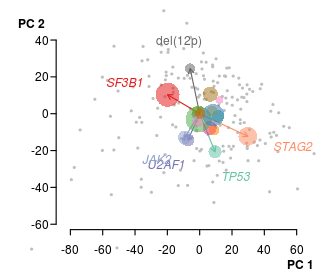

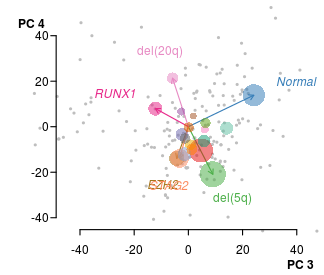

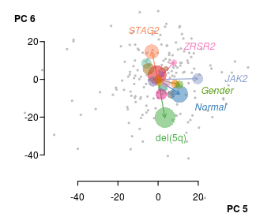

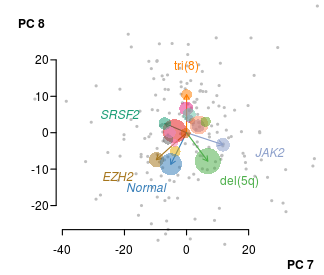

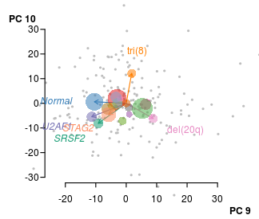

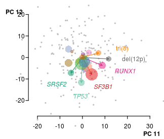

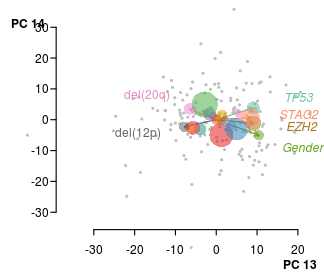

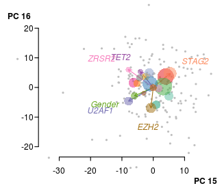

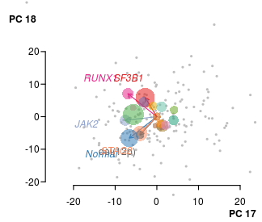

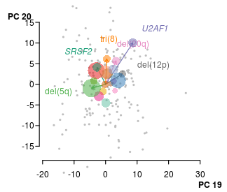

```r
par(bty="n", mgp = c(2,.33,0), mar=c(2,2.5,1,1)+.1, las=1, tcl=-.25, xpd=NA)
glmProjection <-  t(glm$coefficients[,-1] ) %*% pca$rotation[,1:20]
for(i in seq(1,19,2)){
    plot(pca$x[,i + 0:1], col="grey", cex=0.25, pch=19, xlim=range(pca$x[,i])*0.8, ylim=range(pca$x[,i+1])*0.8, xlab="", ylab="")
    u <- matrix(par("usr"), ncol=2)
    r <- sqrt(rowSums(glmProjection[,i + 0:1]^2))
    w <- order(r, decreasing=TRUE)[1:6]
    arrows(0,0,glmProjection[w,i], glmProjection[w,i+1], col=colMutations[w], pch=19, length = 0.05)
    text(glmProjection[w,i+0:1] + (glmProjection[w,i+0:1]/r[w]) * rep(diff(u)*c(0.15,0.1)*1.33, each=6), col=colMutations[w], pch=19, rownames(glmProjection)[w], font=ifelse(grepl("[[:upper:]]",rownames(glmProjection)[w]), 3,1))
    w <- TRUE
    points(glmProjection[w,i+0:1] , col=paste(colMutations[w],"88", sep=""), pch=16, cex=sqrt(colSums(significantGenes)/100)+.5)
    mtext(side=1, at=u[2,1], paste("PC",i), line=1, font=2)
    mtext(side=2, at=u[2,2], paste("PC",i+1), line=.5, font=2)
}
```

### 6. Enrichment of GO Terms in PC1&2

Here we test for an enrichments of GO terms using t-statistics

```r
k = AnnotationDbi::as.list(org.Hs.egGO2EG)
k = k[sapply(k, length)>=10]
c <- pca$rotation[,1:2] *  sqrt(glm$s2.post)
n <- rownames(pca$rotation)
t = mclapply(k, function(p){
            ids = n %in% p
            sapply(1:ncol(c), function(j){
                        if(sum(ids)>2){
                            t <- t.test(c[ids,j], c[!ids,j], alternative="two.sided")
                            v <- var.test(c[ids,j], c[!ids,j], alternative="greater")
                            c(t$p.value, -diff(t$estimate),
                                    v$p.value, v$estimate)
                        }else
                            rep(NA,4)
                    })
        }, mc.cores=1)
GO.pca = matrix(unlist(t), byrow = TRUE, nrow=length(t), dimnames=list(names(t),as.vector(outer(c("pval.t","shift","pval.F","var.odds"),paste(colnames(c), sep=""), paste))))

Term(names(sort(GO.pca[p.adjust(GO.pca[,1],"BH")<0.1,2])[1:20]))
```

```
##                                GO:0005833                                GO:0005344
##                      "hemoglobin complex"             "oxygen transporter activity"
##                                GO:0050832                                GO:0019864
##              "defense response to fungus"                             "IgG binding"
##                                GO:0008009                                GO:0006956
##                      "chemokine activity"                   "complement activation"
##                                GO:0030593                                GO:0071294
##                   "neutrophil chemotaxis"           "cellular response to zinc ion"
##                                GO:0042742                                GO:0006935
##           "defense response to bacterium"                              "chemotaxis"
##                                GO:0090382                                GO:0006968
##                    "phagosome maturation"               "cellular defense response"
##                                GO:0003823                                GO:0006955
##                         "antigen binding"                         "immune response"
##                                GO:0006874                                GO:0031100
##        "cellular calcium ion homeostasis"                      "organ regeneration"
##                                GO:0006783                                GO:0006954
##               "heme biosynthetic process"                   "inflammatory response"
##                                GO:0043202                                GO:0071222
##                         "lysosomal lumen" "cellular response to lipopolysaccharide"
```

```r
Term(names(sort(GO.pca[p.adjust(GO.pca[,1],"BH")<0.1,2], decreasing = TRUE)[1:20]))
```

```
##                                                          GO:0000042
##                                        "protein targeting to Golgi"
##                                                          GO:0030878
##                                         "thyroid gland development"
##                                                          GO:0046854
##                              "phosphatidylinositol phosphorylation"
##                                                          GO:0048853
##                                           "forebrain morphogenesis"
##                                                          GO:0048704
##                           "embryonic skeletal system morphogenesis"
##                                                          GO:0004709
##                                 "MAP kinase kinase kinase activity"
##                                                          GO:0009953
##                                  "dorsal/ventral pattern formation"
##                                                          GO:0007409
##                                                      "axonogenesis"
##                                                          GO:0007276
##                                                 "gamete generation"
##                                                          GO:2000463
## "positive regulation of excitatory postsynaptic membrane potential"
##                                                          GO:0004535
##                            "poly(A)-specific ribonuclease activity"
##                                                          GO:0019083
##                                               "viral transcription"
##                                                          GO:0006415
##                                         "translational termination"
##                                                          GO:0005088
##                    "Ras guanyl-nucleotide exchange factor activity"
##                                                          GO:0009451
##                                                  "RNA modification"
##                                                          GO:0001736
##                                  "establishment of planar polarity"
##                                                          GO:0080182
##                                      "histone H3-K4 trimethylation"
##                                                          GO:0000979
##     "RNA polymerase II core promoter sequence-specific DNA binding"
##                                                          GO:0009952
##                          "anterior/posterior pattern specification"
##                                                          GO:0070528
##                                "protein kinase C signaling cascade"
```

```r
Term(names(sort(GO.pca[p.adjust(GO.pca[,5],"BH")<0.1,6])[1:20]))
```

```
##                                         GO:0008009                                         GO:0030593
##                               "chemokine activity"                            "neutrophil chemotaxis"
##                                         GO:0031663                                         GO:0006935
##    "lipopolysaccharide-mediated signaling pathway"                                       "chemotaxis"
##                                         GO:0050729                                         GO:0006954
##     "positive regulation of inflammatory response"                            "inflammatory response"
##                                         GO:0006968                                         GO:0060333
##                        "cellular defense response"      "interferon-gamma-mediated signaling pathway"
##                                         GO:0045071                                         GO:0071222
##  "negative regulation of viral genome replication"          "cellular response to lipopolysaccharide"
##                                         GO:0010875                                         GO:0006955
##        "positive regulation of cholesterol efflux"                                  "immune response"
##                                         GO:0050830                                         GO:0006928
##      "defense response to Gram-positive bacterium"                      "cellular component movement"
##                                         GO:0030316                                         GO:0042088
##                       "osteoclast differentiation"                  "T-helper 1 type immune response"
##                                         GO:0032695                                         GO:0032715
## "negative regulation of interleukin-12 production"  "negative regulation of interleukin-6 production"
##                                         GO:0090382                                         GO:0009615
##                             "phagosome maturation"                                "response to virus"
```

```r
Term(names(sort(GO.pca[p.adjust(GO.pca[,5],"BH")<0.1,6], decreasing=TRUE)[1:20]))
```

```
##                                                                 GO:0007080
##                                      "mitotic metaphase plate congression"
##                                                                 GO:0007051
##                                                     "spindle organization"
##                                                                 GO:0000940
##                                   "condensed chromosome outer kinetochore"
##                                                                 GO:0000070
##                                     "mitotic sister chromatid segregation"
##                                                                 GO:0000083
## "regulation of transcription involved in G1/S phase of mitotic cell cycle"
##                                                                 GO:0006270
##                                               "DNA replication initiation"
##                                                                 GO:0007076
##                                          "mitotic chromosome condensation"
##                                                                 GO:0042555
##                                                              "MCM complex"
##                                                                 GO:0006271
##                        "DNA strand elongation involved in DNA replication"
##                                                                 GO:0032201
##                   "telomere maintenance via semi-conservative replication"
##                                                                 GO:0000777
##                                         "condensed chromosome kinetochore"
##                                                                 GO:0009982
##                                          "pseudouridine synthase activity"
##                                                                 GO:0000722
##                                   "telomere maintenance via recombination"
##                                                                 GO:0045120
##                                                               "pronucleus"
##                                                                 GO:0034080
##                      "CENP-A containing nucleosome assembly at centromere"
##                                                                 GO:0000775
##                                           "chromosome, centromeric region"
##                                                                 GO:0006297
##                              "nucleotide-excision repair, DNA gap filling"
##                                                                 GO:0005876
##                                                      "spindle microtubule"
##                                                                 GO:0017056
##                                   "structural constituent of nuclear pore"
##                                                                 GO:0007094
##                                      "mitotic spindle assembly checkpoint"
```

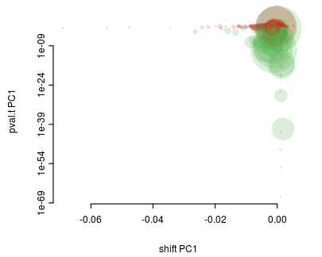

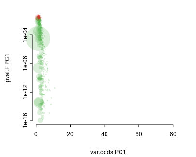

```r
par(bty="n", mgp = c(2,.33,0), mar=c(3,3,1,1)+.1, tcl=-.25, xpd=NA)
for(i in 0:1 * 2)
    plot(GO.pca[GO.pca[,1+i]<0.05,2:1+i], log="y", cex=sqrt(sapply(k[GO.pca[,1+i]<0.05], length)/100), pch=19, col=paste(ifelse(p.adjust(GO.pca[,1+i],"BH")[GO.pca[,1+i]<0.05]<0.1,set1[3],set1[1]),"33", sep=""), lwd=0)
```

```r
write.table(data.frame(GO.id=rownames(GO.pca),
                GO.Term = Term(names(k)) ,
                n.genes = sapply(k, length),
                GO.pca),
        file=paste(Sys.Date(),"-PCA-GO.txt", sep=""), sep="\t", row.names=FALSE, quote=FALSE)
```

### 7. PC rotations

The rotations of the PCs reveal the more influential genes in each component

```r
x <- pca$rotation[,1] * sqrt(glm$s2.post)
y <- pca$rotation[,2] * sqrt(glm$s2.post)
```

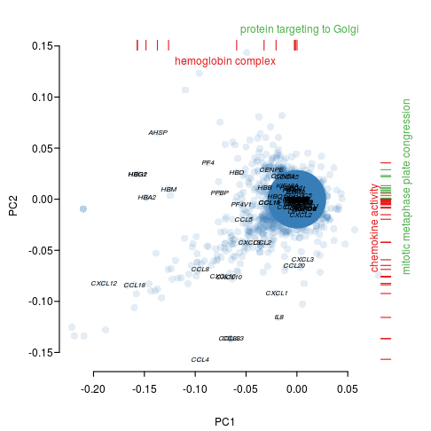

```r
par(bty="n", mgp = c(2,.33,0), mar=c(3,3,2,2)+.1, las=1, tcl=-.25, xpd=NA)
w <- sqrt(x^2 + y^2) > 0.01
plot(x[w],y[w], pch=19, lwd=0, col=paste(set1[2],"22", sep=""), xlab="PC1", ylab="PC2")
points(0,0,pch=19, col=set1[2], cex=8)
up1 <- names(sort(GO.pca[p.adjust(GO.pca[,1],"BH")<0.1,2], decreasing=TRUE)[1])
up2 <- names(sort(GO.pca[p.adjust(GO.pca[,5],"BH")<0.1,6], decreasing=TRUE)[1])
down1 <- names(sort(GO.pca[p.adjust(GO.pca[,1],"BH")<0.1,2])[1])
down2 <- names(sort(GO.pca[p.adjust(GO.pca[,5],"BH")<0.1,6])[1])
rug(x[rownames(pca$rotation) %in% org.Hs.egGO2EG[[down1]]], col=set1[1], lwd=1, side=3)
rug(x[rownames(pca$rotation) %in% AnnotationDbi::mget(up1, org.Hs.egGO2EG)], col=set1[3], lwd=1, side=3)
rug(y[rownames(pca$rotation) %in% org.Hs.egGO2EG[[down2]]], col=set1[1], side=4, lwd=1)
rug(y[rownames(pca$rotation) %in% org.Hs.egGO2EG[[up2]]], col=set1[3], side=4, lwd=1)
w <- rownames(pca$rotation) %in% unlist(AnnotationDbi::mget(c(down1,up1,down2,up2),org.Hs.egGO2EG))
text(x[w], y[w] ,  unlist(AnnotationDbi::mget(rownames(glm)[w], org.Hs.egSYMBOL)), font=3, cex=0.66)
mtext(side=3, at=mean(x[rownames(pca$rotation) %in% org.Hs.egGO2EG[[down1]]]), Term(down1), col=set1[1] , line=-1.5)
mtext(side=3, at=mean(x[rownames(pca$rotation) %in% org.Hs.egGO2EG[[up1]]]), Term(up1), col=set1[3] , line=0.2)
par(las=3)
mtext(side=4, at=mean(y[rownames(pca$rotation) %in% org.Hs.egGO2EG[[down2]]]), Term(down2), col=set1[1] , line=-1.5)
mtext(side=4, at=mean(y[rownames(pca$rotation) %in% org.Hs.egGO2EG[[up2]]]), Term(up2), col=set1[3] , line=0.2)
```

### 8. F and GO

Here we test wether any GO category is associated with higher F-statistics, which would indicate a stronger association of these gene sets with our mutations.

```r
k = AnnotationDbi::as.list(org.Hs.egGO2EG)
k = k[sapply(k, length)>=10]
n <- rownames(pca$rotation)
c <- glm$F
t = sapply(k, function(p){
            ids = n %in% p
            if(sum(ids)>2){
                t <- wilcox.test(c[ids], c[!ids], alternative="greater")
                c(t$p.value, t$statistic/sum(ids)/sum(!ids))
            }else
                rep(NA,2)
        })
GO.F = matrix(t(t), ncol=2, dimnames=list(colnames(t),as.vector(outer(c("pval.U","U"),paste(colnames(c), sep=""), paste))))
colnames(GO.F) <- c("pval.U","U")
sum(p.adjust(GO.F[,1],"BH")<0.1)
```

```
## [1] 349
```

```r
Term(names(tail(sort(GO.F[p.adjust(GO.F[,1],"BH")<0.05,2]), 20)))
```

```
##                                                                 GO:0051537
##                                         "2 iron, 2 sulfur cluster binding"
##                                                                 GO:0048037
##                                                         "cofactor binding"
##                                                                 GO:0004697
##                                                "protein kinase C activity"
##                                                                 GO:0004114
##                       "3',5'-cyclic-nucleotide phosphodiesterase activity"
##                                                                 GO:0035371
##                                                     "microtubule plus end"
##                                                                 GO:0006783
##                                                "heme biosynthetic process"
##                                                                 GO:0071397
##                                         "cellular response to cholesterol"
##                                                                 GO:0005763
##                                    "mitochondrial small ribosomal subunit"
##                                                                 GO:0043220
##                                               "Schmidt-Lanterman incisure"
##                                                                 GO:0000075
##                                                    "cell cycle checkpoint"
##                                                                 GO:0000722
##                                   "telomere maintenance via recombination"
##                                                                 GO:0006271
##                        "DNA strand elongation involved in DNA replication"
##                                                                 GO:0005344
##                                              "oxygen transporter activity"
##                                                                 GO:0051571
##                         "positive regulation of histone H3-K4 methylation"
##                                                                 GO:0000083
## "regulation of transcription involved in G1/S phase of mitotic cell cycle"
##                                                                 GO:0032201
##                   "telomere maintenance via semi-conservative replication"
##                                                                 GO:0006297
##                              "nucleotide-excision repair, DNA gap filling"
##                                                                 GO:0007051
##                                                     "spindle organization"
##                                                                 GO:0006270
##                                               "DNA replication initiation"
##                                                                 GO:0005833
##                                                       "hemoglobin complex"
```

```r
Term(names(head(sort(GO.F[p.adjust(GO.F[,1],"BH")<0.05,1]), 20)))
```

```
##                         GO:0005515                         GO:0005737                         GO:0005634
##                  "protein binding"                        "cytoplasm"                          "nucleus"
##                         GO:0005829                         GO:0005739                         GO:0005654
##                          "cytosol"                    "mitochondrion"                      "nucleoplasm"
##                         GO:0000278                         GO:0005524                         GO:0010467
##               "mitotic cell cycle"                      "ATP binding"                  "gene expression"
##                         GO:0006260                         GO:0006281                         GO:0005813
##                  "DNA replication"                       "DNA repair"                       "centrosome"
##                         GO:0007067                         GO:0051301                         GO:0044281
##                          "mitosis"                    "cell division" "small molecule metabolic process"
##                         GO:0003723                         GO:0005759                         GO:0005743
##                      "RNA binding"             "mitochondrial matrix"     "mitochondrial inner membrane"
##                         GO:0005730                         GO:0006915
##                        "nucleolus"                "apoptotic process"
```

```r
write.table(data.frame(GO.id=rownames(GO.F),
                GO.Term = Term(names(k)) ,
                n.genes = sapply(k, length),
                GO.F,
                adj.P.Val=p.adjust(GO.F[,1], "BH")),
        file=paste(Sys.Date(),"-GO-F.txt", sep=""), sep="\t", row.names=FALSE, quote=FALSE)
```